# 📑 MỤC LỤC

- 0. Import packages and data
- 1. Obtain dependent variable
- 2. Obtain independent variables
  - 2.1. Data Preprocessing:
  - 2.2. Handling Outliers
  - 2.3. Lag Feature Creation
- 3. Univariate Analysis
  - 3.1. Correlation Scoring and Filtering
  - 3.2 Within-Group Variable Selection
- 4. Multivariate Analysis
  - 4.1 Variable Grouping via Clustering
  - 4.2 Model Combination and Estimation
  - 4.3 Model Diagnostics and Filtering
  - 4.4 Champion Model Selection
  - 4.5 Model Evaluation and Output Generation
- 5. PIT PD Calculations
  - 5.1 Calculate portfolio-level count-weighted average TTC PD
  - 5.2 Convert Segment-Level TTC PD to Logit Form
  - 5.3 Scale Logit TTC PD to Match PiT Level & Convert Back

# 0. Import packages and data

```python
import pandas as pd
import numpy as np
from datetime import datetime
import matplotlib.pyplot as plt
import seaborn as sns

import statsmodels.api as sm
import statsmodels.formula.api as smf
from sklearn.linear_model import LinearRegression, LogisticRegression

from statsmodels.stats.outliers_influence import variance_inflation_factor
from statsmodels.stats.stattools import durbin_watson
from statsmodels.stats.diagnostic import het_breuschpagan, normal_ad
from statsmodels.tsa.stattools import adfuller
from scipy import stats

from scipy.cluster.hierarchy import linkage, fcluster, dendrogram
from scipy.spatial.distance import squareform
from sklearn.decomposition import PCA

from sklearn.preprocessing import StandardScaler
from sklearn.model_selection import train_test_split

from sklearn.metrics import mean_squared_error, r2_score, mean_absolute_error
%matplotlib inline
```

```python
#Import all the data from Excel file
file_path = "/Users/redie/Downloads/risk /1. Forecast PD_copy.xlsx"
df = pd.ExcelFile(file_path)
odr_seg_raw = df.parse(df.sheet_names[1])
odr_raw = df.parse(df.sheet_names[2])
hmef_raw = df.parse(df.sheet_names[3])
fmef_raw = df.parse(df.sheet_names[4])
#hmef_raw.head()
```

# 1. Obtain dependent variable

### Objective:

Prepare the observed default rate (ODR) as the target variable in a clean and model-ready format.

### Practice:

Convert the period column to datetime format. Transform ODR values into log-odds (logit) to stabilize variance for linear modeling.

### Input:

odr_raw — raw default rate data 2016 - 2023.

### Output:

odr — a cleaned dataset with the dependent variable expressed in log-odds 2016 - 2023.

```python
#Target variable preparation: Period Conversion & Logit Transformation
odr = odr_raw.copy()
odr["period"] = pd.PeriodIndex(odr["Quý"], freq="Q").to_timestamp(how="end")
odr["logit_odr"] = np.log(odr["ODR"] / (1 - odr["ODR"]))
odr.drop(columns= ['Quý'],inplace=True)

Y = odr[['period', 'logit_odr']].copy()

#odr.head()
```

[output not shown]

# 2. Obtain independent variables

### Objective:

To standardize the format and structure of raw macroeconomic data to ensure consistency and compatibility for downstream steps such as variable generation, modeling, and forecasting.

### Practices:

1. Data Preprocessing: Match variable names and formats between historical and forecast datasets; Standardize the 'period' column to datetime format.
2. Outlier Treatment: Apply winsorization using Z-score method with a threshold of ±3.
3. Lagged Feature Generation: Create lagged versions of all macro variables from lag 1 to lag 4.

### Input:

1. mef_raw containing macroeconomic variables in wide format.

### Output:

1. mef: A cleaned and reshaped MEF (X) dataset (melted long format) spanning 2015–2029.
2. mef_lagged: Dataset containing all X variables including their lagged versions 2015-2029.
3. merged: Dataset containing all X (including their lagged versions) and Y variables 2016-2023.

## 2.1. Data Preprocessing:

Match variable names and formats between historical and forecast datasets; Standardize the 'period' column to datetime format.

```python
# Matching giữa historical và forecasted dataset
mef_raw = pd.merge(fmef_raw, hmef_raw, on="Indicator code", how="inner")
```

```python
#Independent variable preparation
mef = (mef_raw.copy().melt(
        id_vars=["Indicator code"],
        var_name="period",
        value_name="Value"))
mef["period"] = (pd.PeriodIndex(mef["period"], freq="Q")
    .to_timestamp(how="end"))

mef = (mef.pivot(index="period", columns="Indicator code", values="Value").reset_index())
```

## 2.2. Handling Outliers

Outlier Treatment: Apply winsorization using Z-score method with a threshold of ±3.

```python
from scipy.stats import zscore

#Outliers handlings
def winsorize_zscore(series, z_thresh=3):
    """Hàm xử lý outliers bằng z-score và clip về ngưỡng"""
    mu = series.mean()
    sigma = series.std()
    upper = mu + z_thresh * sigma
    lower = mu - z_thresh * sigma
    return series.clip(lower=lower, upper=upper)

mef_cols = mef.columns
mef_winsorized = mef.copy()

# Áp dụng winsorize cho từng cột số
for col in mef_cols:
    mef[col] = winsorize_zscore(mef[col], z_thresh=3)
```

## 2.3. Lag Feature Creation

Lagged Feature Generation: Create lagged versions of all macro variables from lag 1 to lag 4.

```python
#Tạo biến lag. Mef_lag là tổng hợp biến lag, merged là df hoàn chỉnh có lag
lags = [1, 2, 3, 4]

mef_lagged = mef.copy()

for lag in lags:
    lagged = mef.drop(columns='period').shift(lag)
    lagged.columns = [f"{col}_lag{lag}" for col in lagged.columns]
    mef_lagged = pd.concat([mef_lagged, lagged], axis=1)

merged = pd.merge(mef_lagged, Y, on='period', how='inner')
#print(merged)
```

# 3. Univariate Analysis

### Objective:

Identify independent macroeconomic variables with strong univariate relationship to the target, and reduce dimensionality through correlation-based filtering.

### Practice:

1. Compute pairwise correlation between each lagged macro variable and the target variable. Filter variables with absolute correlation > 0.5. Select both: original (non-lagged) variables and lagged variables with the highest abs correlation per group.
2. From each macro group (e.g., X, XG, etc.), retain only one representative variable with the highest correlation.

### Input:

merged — dataset containing both the dependent variable and all lagged macro variables.

### Output:

1. heatmap_data: correlation matrix lagged MEF and Y variable.
2. selected_vars: list of selected lagged variables based on univariate filter
3. ind_vars_final: final list of independent variables after within-group deduplication
4. filtered_df: modeling dataset containing only the selected MEF and Y (2016-2023)

## 3.1. Correlation Scoring and Filtering

Compute pairwise correlation between each lagged macro variable and the target variable. Filter variables with absolute correlation > 0.5. Select both: original (non-lagged) variables and lagged variables with the highest abs correlation per group.

```python
#Vẽ bảng correlations để chọn biến lag

correlations = merged.drop(columns='period').corr()['logit_odr'].drop('logit_odr')
corr_df = correlations.reset_index()
corr_df.columns = ['Variable_lag', 'Correlation']

# Tách tên biến & lag
corr_df['Lag'] = corr_df['Variable_lag'].str.extract(r'lag(\d+)').astype(float)
corr_df['Variable'] = corr_df['Variable_lag'].str.replace(r'_lag\d+', '', regex=True)

# Tạo bảng cho heatmap
heatmap_data = corr_df.pivot(index='Variable', columns='Lag', values='Correlation')
```

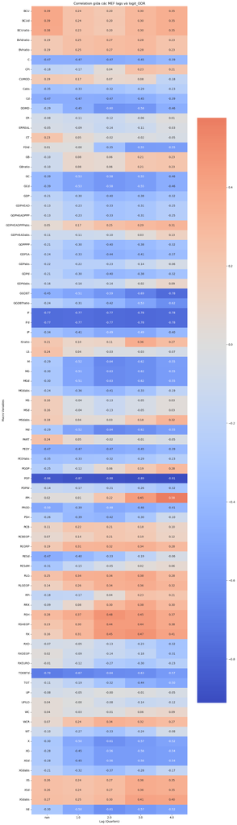

```python
#Vẽ heatmap

plt.figure(figsize=(12, len(heatmap_data) * 0.5))
sns.heatmap(heatmap_data, annot=True, fmt=".2f", cmap="coolwarm", center=0)

plt.title("Correlation giữa các MEF lags và logit_ODR")
plt.xlabel("Lag (Quarters)")
plt.ylabel("Macro Variables")
plt.tight_layout()
plt.show()
```

```python
#Chọn lag

corr_df = correlations.reset_index()
corr_df.columns = ['Variable_lag', 'Correlation']

# Tách lag (NaN nếu không có "_lag")
corr_df['Lag'] = corr_df['Variable_lag'].str.extract(r'lag(\d+)$')[0].astype(float)
corr_df['Variable'] = corr_df['Variable_lag'].str.replace(r'_lag\d+$', '', regex=True)

corr_df['AbsCorr'] = corr_df['Correlation'].abs()

# Lấy lag có abs(corr) cao nhất (khác NaN) cho mỗi biến và > 0.5
filtered_lags = corr_df[(corr_df['Lag'].notna()) & (corr_df['AbsCorr'] >= 0.5)]
best_lags = (
    filtered_lags
    .sort_values(['Variable', 'AbsCorr'], ascending=[True, False])
    .groupby('Variable')
    .first()
    .reset_index())

# Lấy các biến gốc (lag NaN) có tương quan > 0.5
base_vars = corr_df[corr_df['Lag'].isna() & (corr_df['AbsCorr'] >= 0.5)]

# Gộp lại: biến gốc có corr > 0.5 và best lag (dù corr có thể < 0.5)
combined = pd.concat([base_vars, best_lags], ignore_index=True)

# Loại trùng (vì một biến có thể vừa là gốc vừa là lag tốt nhất)
combined = combined.drop_duplicates(subset=['Variable_lag'])

# Lấy danh sách biến
selected_vars = combined['Variable_lag'].tolist()

# Tạo danh sách cột để giữ lại
columns_to_keep1 = ['period', 'logit_odr'] + selected_vars

print(selected_vars)
```

```
['IF', 'IFd', 'POP', 'TDEBTd', 'DOMD_lag2', 'FDId_lag3', 'GC_lag2', 'GCd_lag2', 'GGDBT_lag4', 'GGDBTratio_lag4', 'IF_lag3', 'IFd_lag3', 'M_lag2', 'MG_lag2', 'MGd_lag2', 'Md_lag2', 'POP_lag4', 'PPI_lag4', 'TDEBTd_lag1', 'TOT_lag4', 'X_lag2', 'XG_lag2', 'XGd_lag2', 'Xd_lag2']
```

## 3.2 Within-Group Variable Selection

From each macro group (e.g., X, XG, etc.), retain only one representative variable with the highest correlation.

```python
# Tạo bảng lọc từ corr_df theo các biến đã chọn
selected_df = corr_df[corr_df['Variable_lag'].isin(selected_vars)][
    ['Variable_lag', 'Variable', 'Lag', 'Correlation', 'AbsCorr']
].sort_values(by='AbsCorr', ascending=False).reset_index(drop=True)

# Hiển thị bảng
from IPython.display import display

print("Các biến đã chọn và tương quan của chúng:")
display(selected_df)
```

```
Các biến đã chọn và tương quan của chúng:
```

|  | Variable_lag | Variable | Lag | Correlation | AbsCorr |
| --- | --- | --- | --- | --- | --- |
| 0 | POP_lag4 | POP | 4.0 | -0.911172 | 0.911172 |
| 1 | POP | POP | NaN | -0.855938 | 0.855938 |
| 2 | IFd_lag3 | IFd | 3.0 | -0.784106 | 0.784106 |
| 3 | IF_lag3 | IF | 3.0 | -0.784106 | 0.784106 |
| 4 | GGDBT_lag4 | GGDBT | 4.0 | -0.782328 | 0.782328 |
| 5 | IF | IF | NaN | -0.768447 | 0.768447 |
| 6 | IFd | IFd | NaN | -0.768447 | 0.768447 |
| 7 | TDEBTd | TDEBTd | NaN | -0.702576 | 0.702576 |
| 8 | TDEBTd_lag1 | TDEBTd | 1.0 | -0.671089 | 0.671089 |
| 9 | M_lag2 | M | 2.0 | -0.644578 | 0.644578 |
| 10 | Md_lag2 | Md | 2.0 | -0.644578 | 0.644578 |
| 11 | MG_lag2 | MG | 2.0 | -0.633457 | 0.633457 |
| 12 | MGd_lag2 | MGd | 2.0 | -0.633457 | 0.633457 |
| 13 | GGDBTratio_lag4 | GGDBTratio | 4.0 | -0.617933 | 0.617933 |
| 14 | Xd_lag2 | Xd | 2.0 | -0.613031 | 0.613031 |
| 15 | X_lag2 | X | 2.0 | -0.613031 | 0.613031 |
| 16 | DOMD_lag2 | DOMD | 2.0 | -0.600639 | 0.600639 |
| 17 | PPI_lag4 | PPI | 4.0 | 0.576483 | 0.576483 |
| 18 | GCd_lag2 | GCd | 2.0 | -0.575499 | 0.575499 |
| 19 | GC_lag2 | GC | 2.0 | -0.575499 | 0.575499 |
| 20 | XGd_lag2 | XGd | 2.0 | -0.560792 | 0.560792 |
| 21 | XG_lag2 | XG | 2.0 | -0.560792 | 0.560792 |
| 22 | FDId_lag3 | FDId | 3.0 | -0.553848 | 0.553848 |
| 23 | TOT_lag4 | TOT | 4.0 | -0.503206 | 0.503206 |

```python
ind_vars_final = ['POP_lag4','IFd_lag3', 'TDEBTd','GGDBT_lag4','X_lag2','DOMD_lag2','GCd_lag2','PPI_lag4','FDId_lag3','TOT_lag4']
columns_to_keep2 = ['period', 'logit_odr', 'POP_lag4','IFd_lag3', 'TDEBTd','GGDBT_lag4','X_lag2','DOMD_lag2','GCd_lag2','PPI_lag4','FDId_lag3','TOT_lag4']
filtered_df = merged[columns_to_keep2].copy()

print(columns_to_keep2)
```

```
['period', 'logit_odr', 'POP_lag4', 'IFd_lag3', 'TDEBTd', 'GGDBT_lag4', 'X_lag2', 'DOMD_lag2', 'GCd_lag2', 'PPI_lag4', 'FDId_lag3', 'TOT_lag4']
```

filtered_df là dataset final chứa tất cả các biến độc lập và biến phụ thuộc.

# 4. Multivariate Analysis

### Objective:

To identify a robust and interpretable multivariate regression model explaining the relationship between macroeconomic drivers and observed default rates (ODR), while satisfying core statistical assumptions.

### Input:

1. filtered_df: dataset with selected independent variables and target
2. x_all, y_all: full training data (2016–2023)
3. X_train_full, X_test_full, y_train_full, y_test_full: train-test split
4. X_forecast: independent variables for 2024–2029

### Output:

1. varclus_df: clustering results of macro variables
2. combinations: all model combinations (1 variable per cluster)
3. checklist_df: assumption test results for each model
4. passed_models: subset of models passing all statistical checks
5. esults_df: performance metrics (RMSE, MAE, R², AIC, BIC, etc.)
6. selected_model: variable set of the final champion model
7. champion_model: fitted OLS model object used for prediction
8. df_pit: table containing PiT PD results and their logit values for forecast period

## 4.1 Variable Grouping via Clustering

Use a Python equivalent of SAS PROC VARCLUS to cluster correlated variables. From each cluster, select representative variables for modeling.

### Inter-Variable Correlation Check

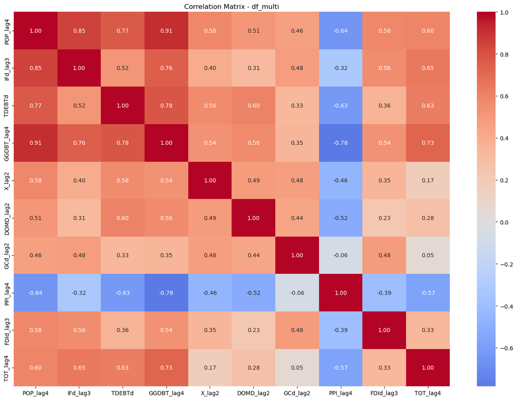

```python
%matplotlib inline

df_multi = filtered_df.drop(columns=['period', 'logit_odr'])
# 2. Vẽ heatmap correlation
plt.figure(figsize=(14, 10))
sns.heatmap(df_multi.corr(), annot=True, fmt=".2f", cmap='coolwarm', center=0)
plt.title('Correlation Matrix - df_multi')
plt.tight_layout()
plt.show()
```

### Variable Clustering (PROC VARCLUS Replication)

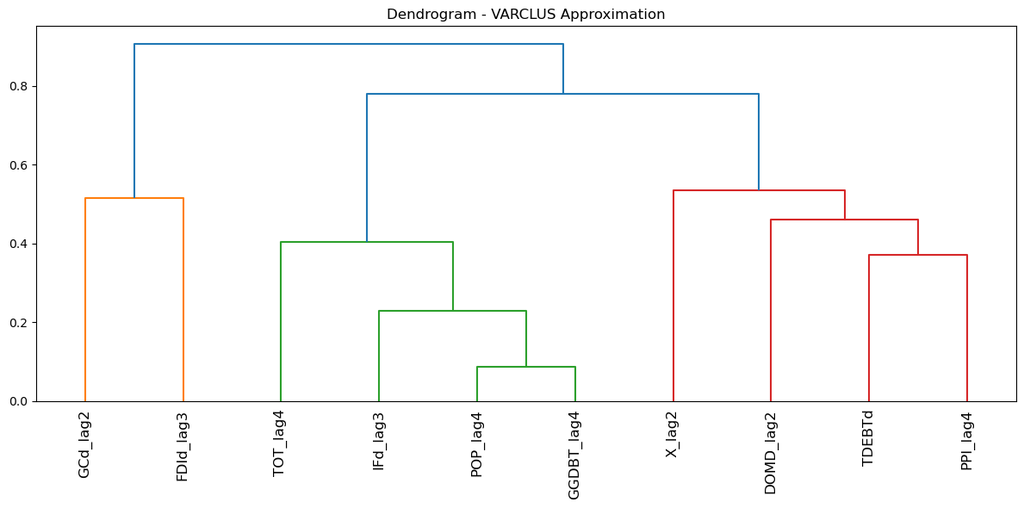

```
Kết quả phân cụm:
     Variable  Cluster
6    GCd_lag2        1
8   FDId_lag3        1
0    POP_lag4        2
1    IFd_lag3        2
3  GGDBT_lag4        2
9    TOT_lag4        2
2      TDEBTd        3
4      X_lag2        3
5   DOMD_lag2        3
7    PPI_lag4        3

Variance explained bởi PC1 trong từng cụm:
   Cluster                                   Variables  Variance_PC1
0        1                       [GCd_lag2, FDId_lag3]         0.990
1        2  [POP_lag4, IFd_lag3, GGDBT_lag4, TOT_lag4]         0.865
2        3       [TDEBTd, X_lag2, DOMD_lag2, PPI_lag4]         0.704
```

```python
cols_to_cluster = ind_vars_final
df_numeric = df_multi[cols_to_cluster]

# Tính ma trận tương quan tuyệt đối
corr_matrix = df_numeric.corr().abs()

# Tính khoảng cách (1 - |correlation|)
distance_matrix = 1 - corr_matrix
np.fill_diagonal(distance_matrix.values, 0)

# Chuyển về condensed form cho clustering
condensed_dist = squareform(distance_matrix)

# Phân cụm bằng hierarchical clustering (phương pháp ward)
Z = linkage(condensed_dist, method='ward')

# Vẽ dendrogram để kiểm tra số cụm (tuỳ chọn)
plt.figure(figsize=(12, 6))
dendrogram(Z, labels=cols_to_cluster, leaf_rotation=90)
plt.title("Dendrogram - VARCLUS Approximation")
plt.tight_layout()
plt.show()

# Cắt thành số cụm mong muốn
k = 3
cluster_labels = fcluster(Z, k, criterion='maxclust')

# Gán cụm cho từng biến
varclus_result = pd.DataFrame({
    'Variable': cols_to_cluster,
    'Cluster': cluster_labels
})

# Đánh giá phương sai giải thích bởi PC1 trong mỗi cụm
variance_explained = []
for cluster_id in sorted(varclus_result['Cluster'].unique()):
    vars_in_cluster = varclus_result[varclus_result['Cluster'] == cluster_id]['Variable'].tolist()
    pca = PCA()
    pca.fit(df_numeric[vars_in_cluster])
    variance_pc1 = pca.explained_variance_ratio_[0]
    variance_explained.append({
        'Cluster': cluster_id,
        'Variables': vars_in_cluster,
        'Variance_PC1': round(variance_pc1, 3)
    })

# Hiển thị kết quả
varclus_df = pd.DataFrame(variance_explained)
print("Kết quả phân cụm:")
print(varclus_result.sort_values("Cluster"))

print("\nVariance explained bởi PC1 trong từng cụm:")
print(varclus_df)
```

```python
#Lấy danh sách tổ hợp biến:

from itertools import product

# Gom các biến thành list theo cụm
grouped_vars = varclus_result.groupby("Cluster")['Variable'].apply(list)

# Kiểm tra có đúng 3 cụm
if len(grouped_vars) != 3:
    raise ValueError(f"Số cụm là {len(grouped_vars)}, cần đúng 3 cụm để tạo mô hình 3 biến.")

# Tạo tất cả tổ hợp 1 biến từ mỗi cụm
combinations = list(product(*grouped_vars))

# Chuyển về DataFrame
combo_df = pd.DataFrame(combinations, columns=['Var1_from_Cluster1', 'Var2_from_Cluster2', 'Var3_from_Cluster3'])

# In kết quả
print("Danh sách các tổ hợp biến (1 từ mỗi cụm):")
print(combinations)
len(combinations)
```

```
Danh sách các tổ hợp biến (1 từ mỗi cụm):
[('GCd_lag2', 'POP_lag4', 'TDEBTd'), ('GCd_lag2', 'POP_lag4', 'X_lag2'), ('GCd_lag2', 'POP_lag4', 'DOMD_lag2'), ('GCd_lag2', 'POP_lag4', 'PPI_lag4'), ('GCd_lag2', 'IFd_lag3', 'TDEBTd'), ('GCd_lag2', 'IFd_lag3', 'X_lag2'), ('GCd_lag2', 'IFd_lag3', 'DOMD_lag2'), ('GCd_lag2', 'IFd_lag3', 'PPI_lag4'), (…
```

```
32
```

## 4.2 Model Combination and Estimation

### Chạy linear regression (OLS) và in kết quả từng mô hình

```python
#Train test split

from sklearn.model_selection import train_test_split
import statsmodels.api as sm

X_all = filtered_df.drop(columns=['logit_odr'])
y_all = filtered_df['logit_odr']

X_train_full, X_test_full, y_train_full, y_test_full = train_test_split(X_all, y_all, test_size=0.2, random_state=42)

# Add constant (intercept) to train and test
#X_train_const = sm.add_constant(X_train)
#X_test_const = sm.add_constant(X_test)
```

```python
for i, combo in enumerate(combinations):
    print(f"\n{'='*80}")
    print(f"📌 Mô hình {i+1} - Biến: {combo}")

    cols = list(combo)
    # ✅ Kiểm tra biến tồn tại trong dữ liệu
    if not set(cols).issubset(X_train_full.columns):
        print(f"❌ Thiếu biến: {set(cols) - set(X_train_full.columns)} → bỏ qua.")
        continue

    # ✅ Chọn biến từ tập đã split
    X_train = X_train_full[cols]
    X_test = X_test_full[cols]
    y_train = y_train_full
    y_test = y_test_full

    # ✅ Thêm constant (intercept)
    X_train_const = sm.add_constant(X_train, has_constant='add')
    X_test_const  = sm.add_constant(X_test, has_constant='add')

    # ✅ Fit mô hình & đánh giá
    try:
        model = sm.OLS(y_train, X_train_const).fit()
        y_pred = model.predict(X_test_const)

        # Metrics
        rmse = np.sqrt(mean_squared_error(y_test, y_pred))
        mae = mean_absolute_error(y_test, y_pred)
        adjr2 = model.rsquared_adj
        aic = model.aic
        bic = model.bic

        print(model.summary())
        print(f"✅ RMSE_test={rmse:.4f} | MAE_test={mae:.4f} | AdjR2_train={adjr2:.4f}")

    except Exception as e:
        print(f"❌ Lỗi với combo {combo}: {e}")
```

```
================================================================================
📌 Mô hình 1 - Biến: ('GCd_lag2', 'POP_lag4', 'TDEBTd')
                            OLS Regression Results
==============================================================================
Dep. Variable:              logit_odr   R-squared:                       0.877
Model:                            OLS   Adj. R-squared:                  0.860
Method:                 Least Squares   F-statistic:                     49.96
Date:                Wed, 23 Jul 2025   Prob (F-statistic):           9.82e-10
Time:                        21:30:05   Log-Likelihood:                 15.830
No. Observations:                  25   AIC:                            -23.66
Df Residuals:                      21   BIC:                            -18.78
Df Model:                           3
Covariance Type:            nonrobust
==============================================================================
                 coef    std err          t      P>|t|      [0.025      0.975]
------------------------------------------------------------------------------
const         -0.8668      0.208     -4.168      0.000      -1.299      -0.434
GCd_lag2      -0.0391      0.018     -2.217      0.038      -0.076      -0.002
POP_lag4      -1.6797      0.242     -6.955      0.000      -2.182      -1.177
TDEBTd        -0.0014      0.007     -0.214      0.833      -0.015       0.012
==============================================================================
Omnibus:                        1.711   Durbin-Watson:                   1.851
Prob(Omnibus):                  0.425   Jarque-Bera (JB):                0.561
Skew:                          -0.219   Prob(JB):                        0.756
Kurtosis:                       3.589   Cond. No.                         117.
==============================================================================

Notes:
[1] Standard Errors assume that the covariance matrix of the errors is correctly specified.
✅ RMSE_test=0.1606 | MAE_test=0.1193 | AdjR2_train=0.8596

================================================================================
📌 Mô hình 2 - Biến: ('GCd_lag2', 'POP_lag4', 'X_lag2')
                            OLS Regression Results
==============================================================================
Dep. Variable:              logit_odr   R-squared:                       0.892
Model:                            OLS   Adj. R-squared:                  0.877
Method:                 Least Squares   F-statistic:                     57.90
Date:                Wed, 23 Jul 2025   Prob (F-statistic):           2.52e-10
Time:                        21:30:05   Log-Likelihood:                 17.460
```

[output cut: 936 more lines]

```
------------------------------------------------------------------------------
const         -2.8257      0.084    -33.581      0.000      -3.001      -2.651
FDId_lag3     -0.0092      0.004     -2.086      0.049      -0.018   -2.87e-05
TOT_lag4      -0.0124      0.033     -0.370      0.715      -0.082       0.057
PPI_lag4       0.0752      0.041      1.835      0.081      -0.010       0.160
==============================================================================
Omnibus:                        1.342   Durbin-Watson:                   1.363
Prob(Omnibus):                  0.511   Jarque-Bera (JB):                1.203
Skew:                           0.394   Prob(JB):                        0.548
Kurtosis:                       2.269   Cond. No.                         25.0
==============================================================================

Notes:
[1] Standard Errors assume that the covariance matrix of the errors is correctly specified.
✅ RMSE_test=0.2142 | MAE_test=0.1815 | AdjR2_train=0.3777
```

## 4.3 Model Diagnostics and Filtering

For each model, test statistical assumptions. Filter out models that violate any of the below.

1. Multicollinearity (Variance Inflation Factor VIF);
2. Residual normality (Shapiro-Wilk test);
3. Homoscedasticity → Breusch-Pagan test;
4. Stationarity (Augmented Dickey-Fuller test);
5. Autocorrelation (Ljung-Box test).

### Define function to test model assumptions

```python
from scipy.stats import shapiro
from statsmodels.stats.outliers_influence import variance_inflation_factor
from statsmodels.stats.diagnostic import het_breuschpagan, acorr_ljungbox
from statsmodels.tsa.stattools import adfuller

def test_model_assumptions(X_train, y_train):
    results = {}

    # Thêm hằng số
    X_const = sm.add_constant(X_train)

    # Fit model OLS
    model = sm.OLS(y_train, X_const).fit()
    residuals = model.resid

    # 1. Multicollinearity
    corr_matrix = X_train.corr().abs()
    max_corr = corr_matrix.where(np.triu(np.ones(corr_matrix.shape), k=1).astype(bool)).max().max()
    vif = [variance_inflation_factor(X_const.values, i) for i in range(X_const.shape[1])]
    max_vif = max(vif[1:])  # bỏ constant

    results['Max |Corr|'] = round(max_corr, 3)
    results['Max VIF'] = round(max_vif, 2)
    results['Pass Multicollinearity'] = (max_corr <= 0.6) and (max_vif <= 5)

    # 2. Residual Normality – Shapiro-Wilk
    _, p_shapiro = shapiro(residuals)
    results['Shapiro-Wilk p'] = round(p_shapiro, 4)
    results['Pass Normality'] = p_shapiro >= 0.05

    # 3. Homoscedasticity – Breusch-Pagan
    _, pval_bp, _, _ = het_breuschpagan(residuals, X_const)
    results['Breusch-Pagan p'] = round(pval_bp, 4)
    results['Pass Homoscedasticity'] = pval_bp >= 0.05

    # 4. Stationarity – Augmented Dickey-Fuller
    adf_p = adfuller(residuals)[1]
    results['ADF p'] = round(adf_p, 4)
    results['Pass Stationarity'] = adf_p < 0.05

    # 5. Autocorrelation – Ljung-Box
    lb_p = acorr_ljungbox(residuals, lags=[min(10, X_train.shape[1])], return_df=True)['lb_pvalue'].iloc[0]
    results['Ljung-Box p'] = round(lb_p, 4)
    results['Pass Autocorrelation'] = lb_p >= 0.05

    return pd.Series(results)
```

### Model Assumption Test Results

```python
full_results = []

for combo in combinations:
    X = filtered_df[list(combo)]
    y = filtered_df['logit_odr']

    metrics = test_model_assumptions(X, y)
    metrics['Variables'] = combo
    full_results.append(metrics)

checklist_df = pd.DataFrame(full_results).sort_values(by='Pass Multicollinearity', ascending=False).reset_index(drop=True)
print(checklist_df)
```

```
    Max |Corr|  Max VIF  Pass Multicollinearity  Shapiro-Wilk p  \
0        0.572     1.60                    True          0.4832
1        0.540     1.76                    True          0.5182
2        0.557     1.53                    True          0.5366
3        0.557     1.55                    True          0.2117
4        0.557     1.75                    True          0.1441
5        0.562     1.98                    True          0.3551
6        0.581     1.95                    True          0.2589
7        0.581     2.00                    True          0.8893
8        0.581     1.64                    True          0.6934
9        0.572     1.49                    True          0.0826
10       0.437     1.35                    True          0.2239
11       0.475     1.33                    True          0.9017
12       0.557     1.57                    True          0.8380
13       0.562     1.62                    True          0.1586
```

[output cut: 120 more lines]

### Selecting Models that Satisfy Statistical Assumptions

```python
# Lọc các hàng mà tất cả kiểm định đều True (loại cột 'Variables' ra khỏi điều kiện)
condition_cols = [col for col in checklist_df.columns if col.startswith('Pass ')]

# Chọn các dòng pass tất cả test
passed_df = checklist_df[checklist_df[condition_cols].all(axis=1)]

# Lấy danh sách combo biến của các mô hình pass test
passed_models = passed_df['Variables'].tolist()

print(passed_models)
len(passed_models)
```

```
[('FDId_lag3', 'IFd_lag3', 'X_lag2'), ('FDId_lag3', 'POP_lag4', 'DOMD_lag2'), ('FDId_lag3', 'POP_lag4', 'X_lag2'), ('GCd_lag2', 'POP_lag4', 'X_lag2'), ('GCd_lag2', 'GGDBT_lag4', 'DOMD_lag2'), ('GCd_lag2', 'GGDBT_lag4', 'X_lag2'), ('GCd_lag2', 'IFd_lag3', 'PPI_lag4'), ('GCd_lag2', 'IFd_lag3', 'X_lag2…
```

```
9
```

## 4.4 Champion Model Selection

```python
from sklearn.metrics import mean_squared_error, mean_absolute_error

def evaluate_on_test_set(passed_models, X_train, y_train, X_test, y_test):
    results = []

    for variables in passed_models:
        try:
            # Chọn biến
            X_train_sel = X_train_full[list(variables)]
            X_test_sel = X_test_full[list(variables)]

            # Thêm hằng số
            X_train_const = sm.add_constant(X_train_sel)
            X_test_const = sm.add_constant(X_test_sel)

            # Fit mô hình
            model = sm.OLS(y_train, X_train_const).fit()

            # Dự báo
            y_pred = model.predict(X_test_const)

            # Tính chỉ số
            rmse = np.sqrt(mean_squared_error(y_test, y_pred))
            mae = mean_absolute_error(y_test, y_pred)
            adj_r2 = model.rsquared_adj
            aic = model.aic
            bic = model.bic

            # Lưu kết quả
            results.append({
                'Variables': variables,
                'Num_Variables': len(variables),
                'Adj_R2_train': round(adj_r2, 4),
                'RMSE_test': round(rmse, 4),
                'MAE_test': round(mae, 4),
                'AIC_train': round(aic, 2),
                'BIC_train': round(bic, 2)
            })

        except Exception as e:
            print(f"Lỗi với mô hình {variables}: {e}")

    return pd.DataFrame(results).sort_values(by='Adj_R2_train')
```

```python
results_df = evaluate_on_test_set(passed_models, X_train_full, y_train_full, X_test_full, y_test_full)
print(results_df)
```

```
                           Variables  Num_Variables  Adj_R2_train  RMSE_test  \
4  (GCd_lag2, GGDBT_lag4, DOMD_lag2)              3        0.6743     0.1537
5     (GCd_lag2, GGDBT_lag4, X_lag2)              3        0.6778     0.1587
0      (FDId_lag3, IFd_lag3, X_lag2)              3        0.7264     0.2281
7       (GCd_lag2, IFd_lag3, X_lag2)              3        0.7279     0.2211
6     (GCd_lag2, IFd_lag3, PPI_lag4)              3        0.7568     0.1082
1   (FDId_lag3, POP_lag4, DOMD_lag2)              3        0.8603     0.1670
2      (FDId_lag3, POP_lag4, X_lag2)              3        0.8649     0.2251
3       (GCd_lag2, POP_lag4, X_lag2)              3        0.8767     0.1974
8    (GCd_lag2, POP_lag4, DOMD_lag2)              3        0.8797     0.1585

   MAE_test  AIC_train  BIC_train
4    0.1176      -2.63       2.25
5    0.1133      -2.90       1.98
0    0.1972      -6.99      -2.12
7    0.1889      -7.12      -2.25
6    0.0822      -9.93      -5.05
1    0.1228     -23.79     -18.92
2    0.2011     -24.63     -19.76
3    0.1681     -26.92     -22.04
8    0.1217     -27.53     -22.66
```

```python
best_model_index = results_df["RMSE_test"].idxmin()
selected_model = passed_models[best_model_index]
print (selected_model)
```

```
('GCd_lag2', 'IFd_lag3', 'PPI_lag4')
```

### 4.5 Model Evaluation and Output Generation

```python
# Lấy đúng biến của champion model
X_champion = X_train_full[list(selected_model)]
X_champion_const = sm.add_constant(X_champion)

# Fit lại model
champion_model = sm.OLS(y_train, X_champion_const).fit()

# Kiểm tra summary nếu cần
print(champion_model.summary())
```

```
                            OLS Regression Results
==============================================================================
Dep. Variable:              logit_odr   R-squared:                       0.787
Model:                            OLS   Adj. R-squared:                  0.757
Method:                 Least Squares   F-statistic:                     25.89
Date:                Wed, 23 Jul 2025   Prob (F-statistic):           2.99e-07
Time:                        21:30:09   Log-Likelihood:                 8.9643
No. Observations:                  25   AIC:                            -9.929
Df Residuals:                      21   BIC:                            -5.053
Df Model:                           3
Covariance Type:            nonrobust
==============================================================================
                 coef    std err          t      P>|t|      [0.025      0.975]
------------------------------------------------------------------------------
const         -2.1488      0.125    -17.239      0.000      -2.408      -1.890
GCd_lag2      -0.0649      0.024     -2.688      0.014      -0.115      -0.015
IFd_lag3      -0.0664      0.017     -3.801      0.001      -0.103      -0.030
PPI_lag4       0.0710      0.022      3.269      0.004       0.026       0.116
==============================================================================
Omnibus:                        4.474   Durbin-Watson:                   1.897
Prob(Omnibus):                  0.107   Jarque-Bera (JB):                2.905
Skew:                           0.807   Prob(JB):                        0.234
Kurtosis:                       3.426   Cond. No.                         30.2
==============================================================================

Notes:
[1] Standard Errors assume that the covariance matrix of the errors is correctly specified.
```

```python
#Tách forecast window
X_forecast = mef_lagged[mef_lagged['period'] >= '2024-01-01'].copy()
```

```python
# Chuẩn bị dữ liệu với đúng biến
X_forecast_var = sm.add_constant(X_forecast[list(selected_model)], has_constant='add')

# Dự báo
y_pred_log = champion_model.predict(X_forecast_var)
y_pred = np.exp(y_pred_log)  # nếu đã log target

# Gộp lại
df_forecast = X_forecast.copy()
df_forecast['pit_pd'] = y_pred
df_forecast['logit_pit_pd'] = y_pred_log

df_forecast.head()
```

|  | period | BCU | BCUd | BCUratio | BVIdratio | BVIratio | C | CPI | CUMOD | Cabs | ... | X_lag4 | XG_lag4 | XGd_lag4 | XGdabs_lag4 | XS_lag4 | XSd_lag4 | XSdabs_lag4 | Xd_lag4 | pit_pd | logit_pit_pd |
| --- | --- | --- | --- | --- | --- | --- | --- | --- | --- | --- | --- | --- | --- | --- | --- | --- | --- | --- | --- | --- | --- |
| 36 | 2024-03-31 23:59:59.999999999 | 162.07 | 151.42 | 138.23 | 32.19 | 32.19 | 4.89 | 3.77 | -64.91 | 7.26 | ... | -5.67 | -9.01 | -9.01 | -11.59 | 155.43714 | 155.43714 | 158.595564 | -5.67 | 0.073728 | -2.607370 |
| 37 | 2024-06-30 23:59:59.999999999 | -51.70 | -55.11 | -56.56 | -32.43 | -32.43 | 6.85 | 4.39 | -8.88 | 9.48 | ... | -6.01 | -8.01 | -8.01 | -11.06 | 61.10000 | 61.10000 | 57.230000 | -6.01 | 0.061928 | -2.781783 |
| 38 | 2024-09-30 23:59:59.999999999 | -33.56 | -36.42 | -40.44 | -27.12 | -27.12 | 7.20 | 3.48 | -14.42 | 10.04 | ... | 4.04 | 2.86 | 2.86 | -2.38 | 30.12000 | 30.12000 | 24.930000 | 4.04 | 0.053676 | -2.924795 |
| 39 | 2024-12-31 23:59:59.999999999 | -45.17 | -46.48 | -50.30 | -23.99 | -23.99 | 7.19 | 2.72 | -8.99 | 10.20 | ... | 11.55 | 11.17 | 11.17 | 7.86 | 14.38000 | 14.38000 | 15.220000 | 11.55 | 0.058780 | -2.833960 |
| 40 | 2025-03-31 23:59:59.999999999 | 9.40 | 6.07 | -1.78 | -11.26 | -11.26 | 6.10 | 2.86 | -63.74 | 10.12 | ... | 17.96 | 18.00 | 18.00 | 16.75 | 28.79000 | 28.79000 | 22.850000 | 17.96 | 0.048704 | -3.021989 |

5 rows × 418 columns

```python
# Lọc các năm cần lấy
years = [2025, 2026, 2027]

# Lấy dòng cuối cùng của mỗi năm theo 'period'
df_forecast_year = (
    df_forecast[df_forecast['period'].dt.year.isin(years)]
    .sort_values('period')
    .groupby(df_forecast['period'].dt.year)
    .tail(1)
    .copy())

# Chỉ lấy các cột cần thiết
df_pit = df_forecast_year[['period', 'pit_pd', 'logit_pit_pd']]

# Hiển thị kết quả
print(df_pit)
```

```
                          period    pit_pd  logit_pit_pd
43 2025-12-31 23:59:59.999999999  0.062104     -2.778948
47 2026-12-31 23:59:59.999999999  0.063521     -2.756384
51 2027-12-31 23:59:59.999999999  0.075736     -2.580497
```

# 5. PIT PD Calculations

### Objective:

To convert Basel TTC PDs into forward-looking PiT PDs using macroeconomic forecasts, ensuring consistency between segment-level and portfolio-level risk.

### Practices:

1. Compute portfolio-level TTC PD by taking the count-weighted average of historical segment-level TTC PDs (2016–2023), using the borrower distribution as of 31.12.2024.
2. Convert segment-level TTC PDs to logit form to establish a baseline in log-odds space.
3. For each forecast year (e.g., 2025–2027), compute the portfolio-level count-weighted average of predicted logit PiT PD from pit_df. Calculate a scalar (α) for each year as the ratio between weighted logit PiT and weighted logit TTC; apply it to scale all segment-level logit TTC PDs; convert the result back to PD scale via inverse logit.

### Input:

pit_df: forecasted logit PiT PDs at the end of 2025, 2026, 2027. odr_seg_raw: historical average TTC PDs by segments and borrower counts per segment as of 31.12.2024.

### Output:

df_scaled: final result table containing year, segment, scaled_logit_pit_pd, scaled_pit_pd, and alpha.

```python
print(odr_seg_raw)
odr_seg_raw.rename(columns={'num/-obligors2014': 'num_obg_2024'}, inplace=True)
```

```
  rating  avg_pd_16_23  num/-obligors2014
0     S1         0.006                 72
1     S2         0.013                166
2     S3         0.034                634
3     S4         0.045                774
4     S5         0.080               1497
5     S6         0.546                 97
```

## 5.1 Calculate portfolio-level count-weighted average TTC PD

Compute portfolio-level TTC PD by taking the count-weighted average of historical segment-level TTC PDs (2016–2023), using the borrower distribution as of 31.12.2024.

```python
weighted_ttc_pd = (
    (odr_seg_raw['avg_pd_16_23'] * odr_seg_raw['num_obg_2024']).sum()
    / odr_seg_raw['num_obg_2024'].sum()
)

print(f'Portfolio-level TTC PD (count-weighted): {weighted_ttc_pd:.4f}')
```

```
Portfolio-level TTC PD (count-weighted): 0.0715
```

## 5.2 Convert Segment-Level TTC PD to Logit Form

Convert segment-level TTC PDs to logit form to establish a baseline in log-odds space.

```python
# Clip PD để tránh lỗi log(0)
pd_clipped = odr_seg_raw['avg_pd_16_23'].clip(1e-6, 1 - 1e-6)

# Tính logit PD
odr_seg_raw['logit_ttc_pd'] = np.log(pd_clipped / (1 - pd_clipped))

# Kiểm tra
print(odr_seg_raw[['rating', 'avg_pd_16_23', 'logit_ttc_pd']])
```

```
  rating  avg_pd_16_23  logit_ttc_pd
0     S1         0.006     -5.109978
1     S2         0.013     -4.329721
2     S3         0.034     -3.346803
3     S4         0.045     -3.055049
4     S5         0.080     -2.442347
5     S6         0.546      0.184522
```

## 5.3 Scale Logit TTC PD to Match PiT Level & Convert Back

1. For each year, compute scalar α = (weighted avg logit PiT) / (weighted avg logit TTC).
2. Multiply each segment’s logit TTC PD by α to get scaled logit PiT PD.
3. Convert back from logit to PD scale using logistic function.

This gives final 12-month PiT PD per segment for each forecast year.

```python
# Chuẩn bị đầu vào
logit_ttc = odr_seg_raw['logit_ttc_pd'].values                # TTC PD đã logit
weights_raw = odr_seg_raw['num_obg_2024'].values              # số lượng KH theo phân khúc
weights = weights_raw / weights_raw.sum()                     # normalize để thành trọng số

ratings = odr_seg_raw['rating'].values                        # optional: gắn tên phân khúc
years = [2025, 2026, 2027]

results = []

# Loop qua từng năm cuối
for year in years:
    # Lấy logit_pit_pd tại cuối năm đó
    pit_row = (
        df_pit[df_pit['period'].dt.year == year]
        .sort_values('period')
        .iloc[-1]
    )

    # Lấy vector logit_pit_pd (giả định theo từng segment)
    logit_pit_vec = pit_row['logit_pit_pd']

    # Nếu là scalar (dự báo chung), nhân bản ra vector
    if np.isscalar(logit_pit_vec):
        logit_pit_vec = np.full_like(logit_ttc, logit_pit_vec)

    # Tính trung bình trọng số
    wavg_logit_pit = np.average(logit_pit_vec, weights=weights)
    wavg_logit_ttc = np.average(logit_ttc, weights=weights)

    # Tính scalar alpha
    alpha = wavg_logit_pit / wavg_logit_ttc

    # B4: Scale TTC PD & convert sang PiT PD
    scaled_logit = alpha * logit_ttc
    scaled_pd = 1 / (1 + np.exp(-scaled_logit))

    # Ghi lại kết quả cho từng segment
    for i in range(len(logit_ttc)):
        results.append({
            'year': year,
            'alpha': alpha,
            'segment': ratings[i],
            'scaled_logit_pit_pd': scaled_logit[i],
            'scaled_pit_pd': scaled_pd[i]
        })

# Đưa vào DataFrame
df_scaled = pd.DataFrame(results)

# Hiển thị
print(df_scaled)
```

```
    year     alpha segment  scaled_logit_pit_pd  scaled_pit_pd
0   2025  0.977459      S1            -4.994792       0.006728
1   2025  0.977459      S2            -4.232123       0.014314
2   2025  0.977459      S3            -3.271362       0.036567
3   2025  0.977459      S4            -2.986184       0.048054
4   2025  0.977459      S5            -2.387293       0.084147
5   2025  0.977459      S6             0.180362       0.544969
6   2026  0.969522      S1            -4.954237       0.007004
7   2026  0.969522      S2            -4.197761       0.014807
8   2026  0.969522      S3            -3.244800       0.037514
9   2026  0.969522      S4            -2.961938       0.049175
10  2026  0.969522      S5            -2.367910       0.085653
11  2026  0.969522      S6             0.178898       0.544606
12  2027  0.907656      S1            -4.638103       0.009583
13  2027  0.907656      S2            -3.929898       0.019267
14  2027  0.907656      S3            -3.037747       0.045749
15  2027  0.907656      S4            -2.772934       0.058804
16  2027  0.907656      S5            -2.216811       0.098251
17  2027  0.907656      S6             0.167482       0.541773
```

```python
#df_scaled.to_excel("PIT_PD_results.xlsx", sheet_name="PIT PD results", index=False)
```